# Experimental Economics: Data Workflow

: Data Presentation

Author

Matteo Ploner

Published

May 9, 2023

# 1 Data Representation

## 1.1 A Grammar for graphics

- Wickham (2010) defines a layered grammar of graphics
  - Buiding a graph from multiple layers of data
- The main layers of a graph are
  - *data and aesthetic* mappings
  - *geometry objects*
  - *scales*
  - *facet specification*
- In addition we may have
  - *statistical transformations*
  - *coordinate system*

## 1.2 ggplot

- We rely on the library *ggplot2* to provide a graphical representation of data
  - Provide a data frame in the form of a tibble
  - Define the aesthetic mapping gathered from the data frame
    - *x*: x-dimension
    - *y*: y-dimension
    - *fill*: color to fill the graph
    - *color*: color of the graph
    - *size*: dimension of graph elements
    - *label*: labels in the graph

```r
ggplot(data=“DATA”, mapping=aes(x=“X”,y=“Y”,...))
```

- This “sets the ground” for the graph
  - Still need to specify the exact “geometry” of the graph

```r
dt = tibble(x=1:10,y=x^2)
dt
```

```
# A tibble: 10 × 2
       x     y
   <int> <dbl>
 1     1     1
 2     2     4
 3     3     9
 4     4    16
 5     5    25
 6     6    36
 7     7    49
 8     8    64
 9     9    81
10    10   100
```

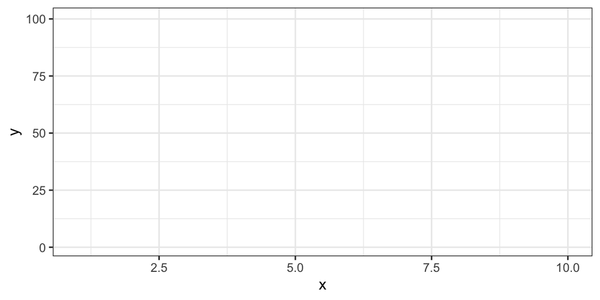

```r
ggplot(data=dt, aes(x=x,y=y))
```

## 1.3 Geometry

### 1.3.1 geom_point()

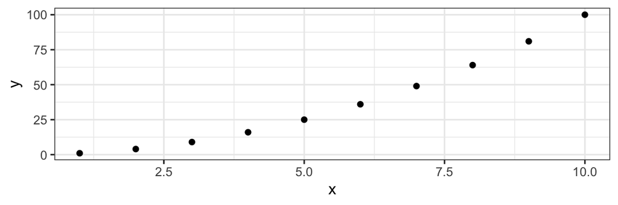

```r
ggplot(data=dt, aes(x=x,y=y))+
  geom_point()
```

### 1.3.2 geom_line()

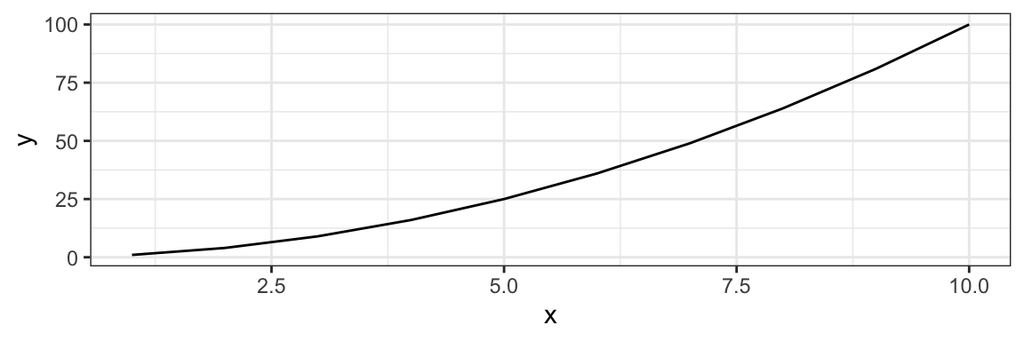

```r
ggplot(data=dt, aes(x=x,y=y))+
geom_line()
```

### 1.3.3 geom_col()

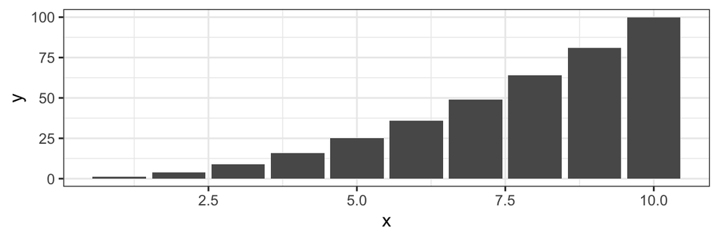

```r
ggplot(data=dt, aes(x=x,y=y))+
geom_col()
```

### 1.3.4 Combined

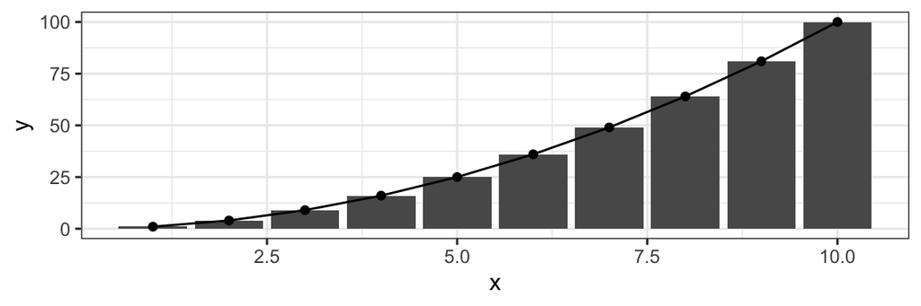

```r
ggplot(data=dt, aes(x=x,y=y))+
  geom_col()+
  geom_line()+
  geom_point()
```

## 1.4 Markers

### 1.4.1 Lines

- *linetype* controls the style of line
  - Can also be used inside *aes(linetype=)* when line type is conditional upon a viariable

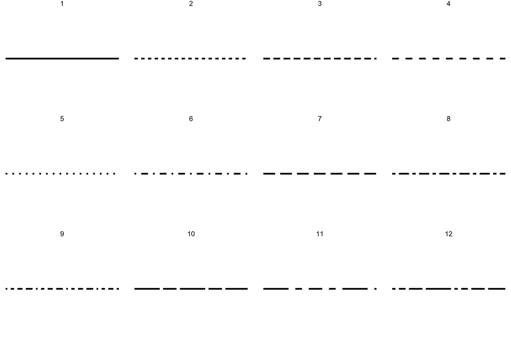

### 1.4.2 Points

- *pch* controls the style of points
  - Can be used inside *aes(pch=)* when point type is conditional upon a viariable

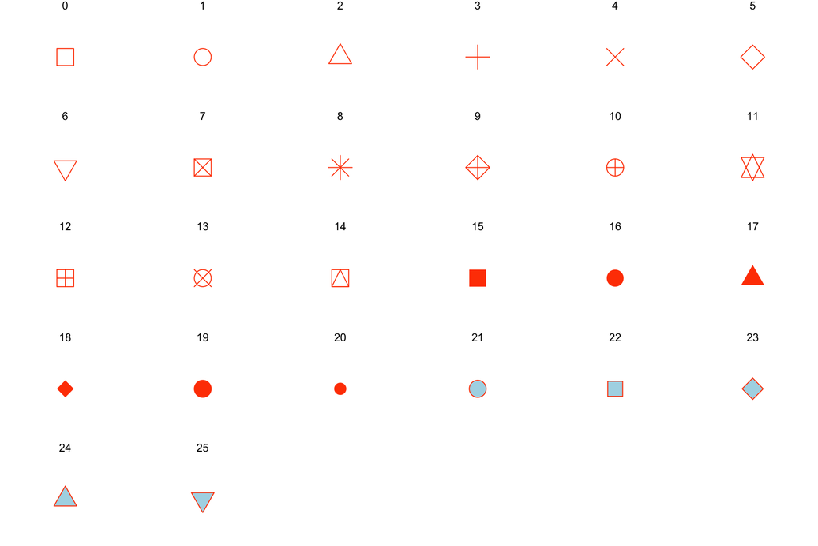

## 1.5 Markers: example

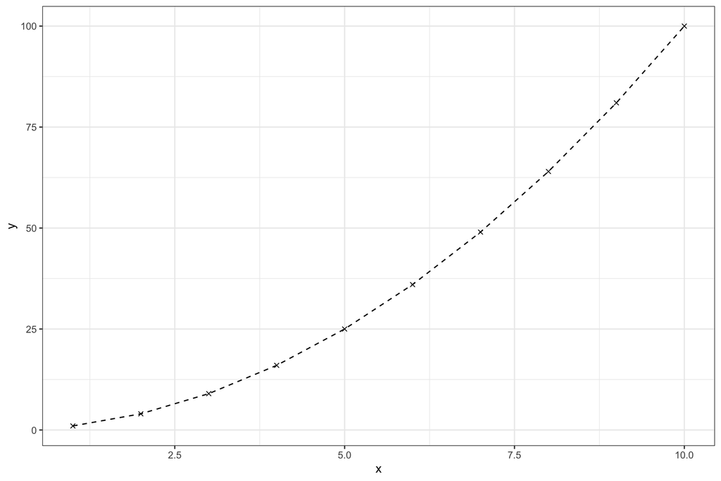

```r
ggplot(data=dt, aes(x=x,y=y))+
    geom_point(pch=4)+
    geom_line(linetype=2)
```

## 1.6 Axes

- Axes provide a guide to read the graph
- Possible to control
  - axis dimensions
  - axis type
  - tick marks
  - tick mark labels

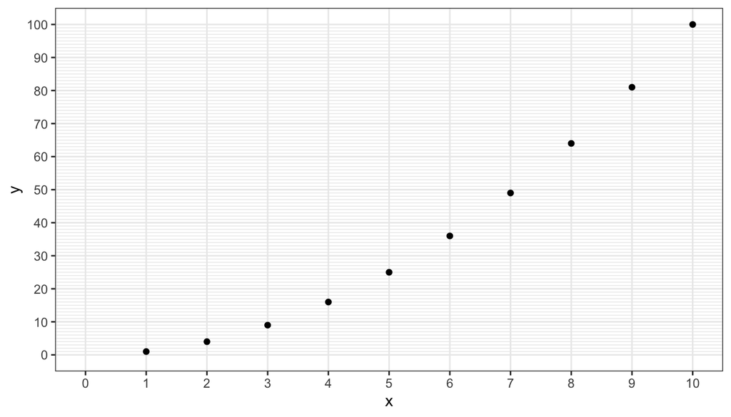

```r
ggplot(data=dt, aes(x=x,y=y))+
    geom_point()+
        scale_x_continuous(
          limits=c(0,max(dt$x)),
          minor_breaks=seq(0,10,1),
          breaks=seq(0,10,1),
          labels=seq(0,10,1)
        )+
        scale_y_continuous(
          limits=c(0,max(dt$y)),
          minor_breaks=seq(0,max(dt$y),1),
          breaks=seq(0,max(dt$y),10),
          labels=seq(0,max(dt$y),10)
        )
```

# 2 Non graphical elements

## 2.1 Labels

- We can specify labels of the graph
  - Title
  - Axis labels
  - Caption

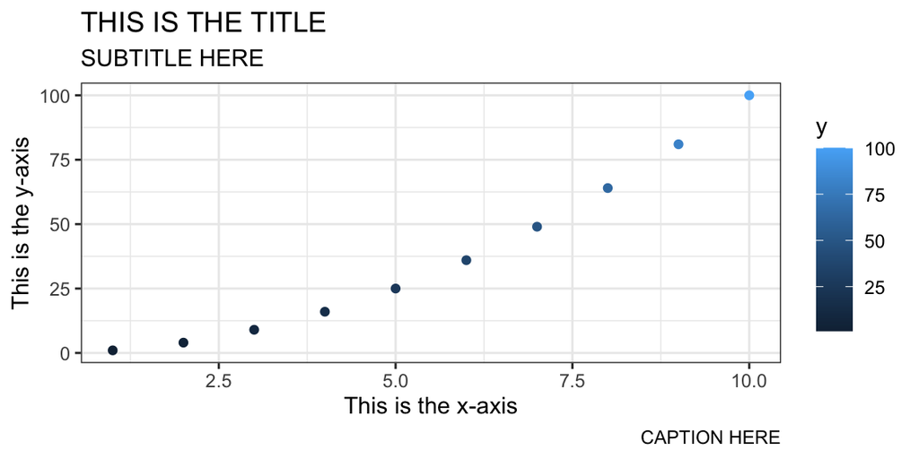

```r
ggplot(data=dt, aes(x=x,y=y,color=y))+
  geom_point()+
    labs(
      title="THIS IS THE TITLE",
      subtitle="SUBTITLE HERE",
      y = "This is the y-axis",
      x= "This is the x-axis",
      caption="CAPTION HERE"
      )
```

## 2.2 Themes

- You can easily control the *size, the orientation, and the color* of non-graphical elements with *theme*
  - Axis
    - axis.title, axis.text, legend.key, legend.key.size …
  - Legend
    - legend.background, legend.margin, legend.spacing, legend.key.height, legend.key.width, legend.text, legend.text.align, legend.title, legend.position …
  - Facets
    - strip.background, strip.text …

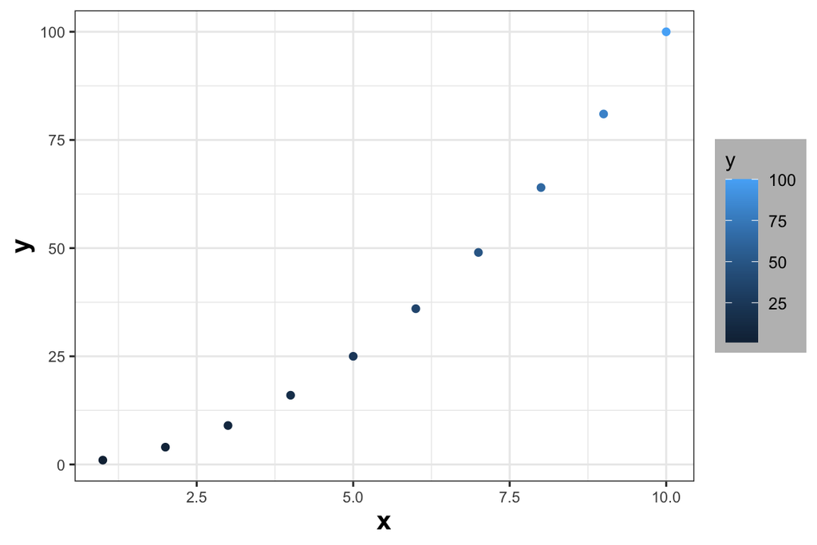

```r
ggplot(data=dt, aes(x=x,y=y,color=y))+
      geom_point()+
        theme(
              legend.position="right",
              axis.text=element_text(size=8),
              axis.title=element_text(size=14,face="bold"),
              legend.background = element_rect(fill="grey", size=2, linetype="solid")
              )
```

## 2.3 Colors

- Colours can be used to *fill* a geometric element (e.g., bars, points) or to define its *color* (e.g., points, lines, …)
- Colours can also be used to map variables to colors
  - *aes(… color=VAR, fill=VAR)*
- Fill and color for a discrete variable
  - *scale_fill_brewer()** or *scale_color_brewer()** to use *library(RColorBrewer)* palettes
  - *scale_fill_manual()* or *scale_color_manual()* to manually define colors
- Fill and color for a continuous variable
  - *scale_fill_gradient()* or *scale_color_gradient()* two-color gradient
  - *scale_fill_gradientn()* or *scale_color_gradientn()* n-color gradient, equally spaced

## 2.4 RColorBrewer palettes

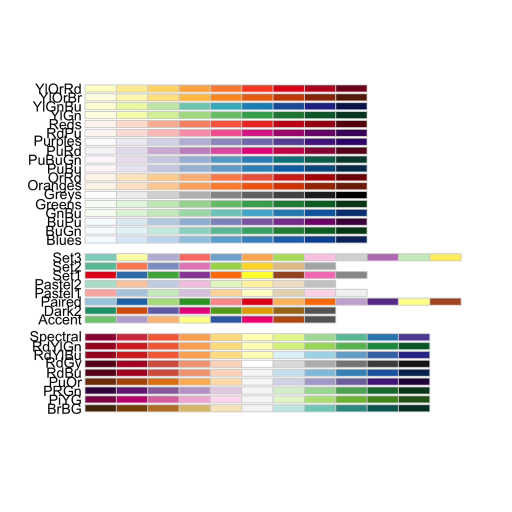

## 2.5 Colors

- Use color to provide a measure of the y-value

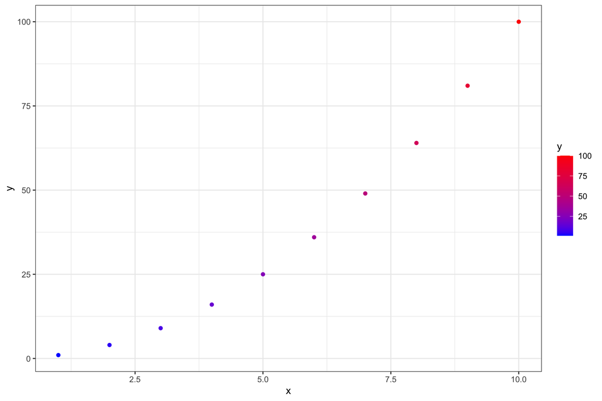

```r
ggplot(data=dt, aes(x=x,y=y,color=y))+
  geom_point()+
    scale_colour_gradient(low="Blue",high="Red")
```

- Use color to distinguish between Odd and Even x-values (discrete mapping)

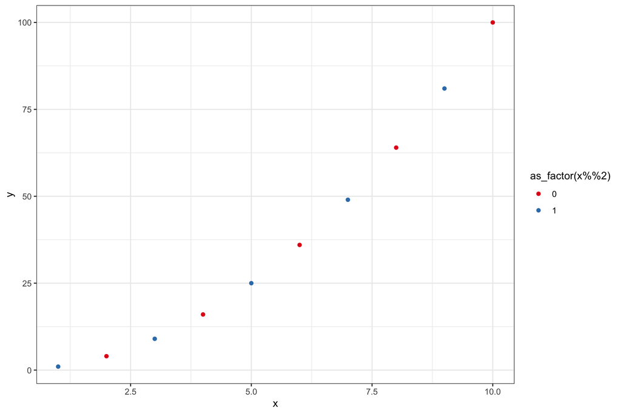

```r
# CODE HERE
ggplot(data=dt, aes(x=x,y=y,colour=as_factor(x%%2)))+
  geom_point()+
    scale_colour_brewer(palette="Set1")
```

## 2.6 Default themes

- We can modify the theme of the graph vith *theme*
  - Overall look
  - Position of the legend
  - Font size
  - …
- A gallery of themes can be found [here](https://ggplot2.tidyverse.org/reference/ggtheme.html)

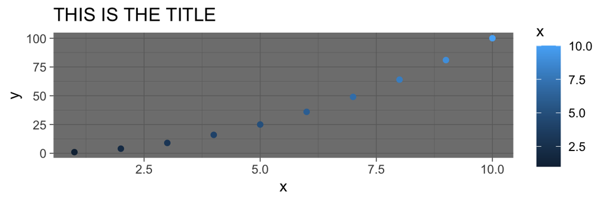

```r
ggplot(data=dt, aes(x=x,y=y, color=x))+
  geom_point()+
  theme_dark()+
      labs(
      title="THIS IS THE TITLE"
      )
```

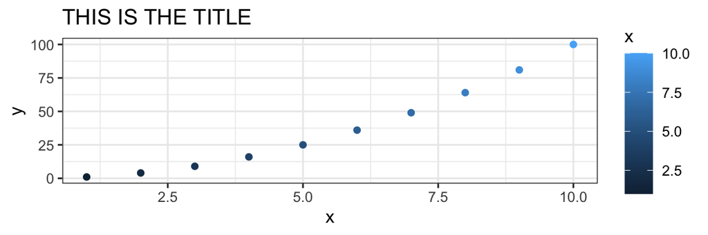

```r
ggplot(data=dt, aes(x=x,y=y, color=x))+
  geom_point()+
  theme_bw()+
      labs(
      title="THIS IS THE TITLE"
      )
```

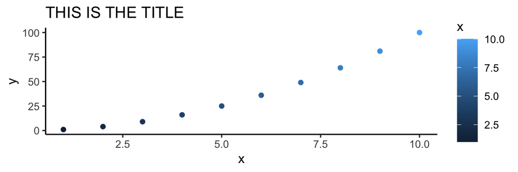

```r
ggplot(data=dt, aes(x=x,y=y, color=x))+
  geom_point()+
  theme_classic()+
    labs(
      title="THIS IS THE TITLE"
      )
```

## 2.7 Facets

- We can “split” different values into different indpendent panels
  - Facets conditiona upon a variable
- As an example, divide odd and even outcomes

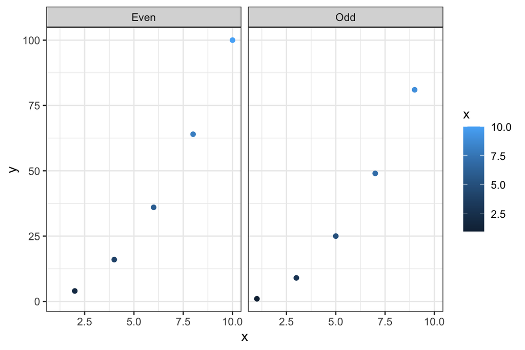

```r
ggplot(data=dt, aes(x=x,y=y, color=x))+
  geom_point()+
  facet_wrap(~ifelse(x%%2==0,"Even","Odd"))
```

## 2.8 Combining layers

- Now we can combine different layers of graphical and non-graphical elements to get the desired output

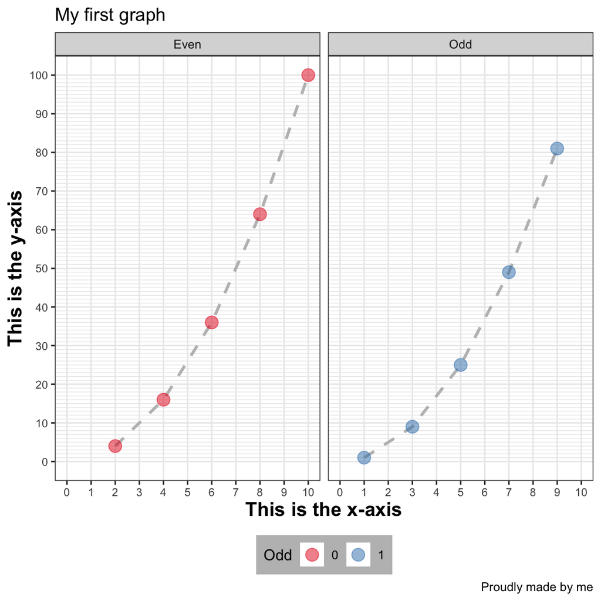

```r
 g <-
ggplot(data=dt, aes(x=x,y=y, color=as_factor(x%%2)))+
  geom_line(linetype=2, size=1, color="grey" )+
  geom_point(size=4, alpha=.5)+
    scale_x_continuous(
    limits=c(0,max(dt$x)),
    minor_breaks=seq(0,10,1),
    breaks=seq(0,10,1),
    labels=seq(0,10,1)
    )+
    scale_y_continuous(
    limits=c(0,max(dt$y)),
    minor_breaks=seq(0,max(dt$y),1),
    breaks=seq(0,max(dt$y),10),
    labels=seq(0,max(dt$y),10)
    )+
      facet_wrap(~ifelse(x%%2==0,"Even","Odd"))+
        scale_colour_brewer(palette="Set1")+
        theme_bw()+
          labs(
              title="My first graph",
              y = "This is the y-axis",
              x= "This is the x-axis",
              caption="Proudly made by me",
              color="Odd"
          )+
          theme(
                legend.position="bottom",
                axis.text=element_text(size=8),
                axis.title=element_text(size=14,face="bold"),
                legend.background = element_rect(fill="grey",
                size=2, linetype="solid")
          )
```

# 3 eporting

## 3.1 R markdown

- What is R Markdown?
  - It combines the simple style of Markdown and the powerful computational environment of R
  - R Markdown provides an authoring framework for data science.
  - A single R Markdown file to both save and execute code
  - Generate high quality reports that can be shared with an audience.
- We rely on [*Quarto*](https://quarto.org/docs/computations/r.html) to create a report from R Markdown
  - A multi-language, next generation version of R Markdown from RStudio, with many new features and capabilities.

[video not shown]

- See the official guide [here](https://quarto.org/docs/guide/)

## 3.2 R Markdown: elements

- A R Markdown document is made of 3 main components
  1. *Markdown textual elements*
     - Contains the text comment/description of the output of the R chunk code
  2. *R chunk code*
     - Contains the R code to generate the desired output (table, graph, results…)
  3. *YAML header*
     - Contains information about the document and formatting styles

## 3.3 Textual elements

- Markdown is a lightweight markup language with plain text formatting syntax

```
Plain text
*italics* and _italics_
**bold** and __bold__
superscript^2^
~~strikethrough~~
[link](www.rstudio.com)
inline equation: $A = \pi*r^{2}$
```

Plain text  
*italics* and *italics*  
**bold** and **bold**  
superscript<sup>2</sup>  
strikethrough  
link  
inline equation: $A = \pi*r^{2}$

## 3.4 What is a chunk code?

- You can insert R code into a chunk code
- The chunk has this generic format

````
``` {r}
Your code here
```
````

- Several features of the code chunk can be controlled (see [here](https://bookdown.org/yihui/rmarkdown/r-code.html) for a detailed list)
  - *eval*
    - =FALSE $\Rightarrow$ the chunk is not evaluated
  - *echo*
    - =FALSE $\Rightarrow$ no source code is printed in the output, only the result of the code
  - *include*
    - =FALSE $\Rightarrow$ the chunk is excluded from the output, but still evaluated
  - *warning, message, and error*
    - =FALSE $\Rightarrow$ warnings, messages and errors are not printed in the output
- One can also control figure dimensions (in inches) with *fig.width* and *fig.height*

````
``` {r}
#| echo=FALSE
#| include=TRUE
#| eval=TRUE
#| fig.width=9
#| fig.height=6

Your code here
```
````

## 3.5 What is the YAML header?

- The YAML header contains the properties of the document
  - Title, author, date
  - The output format
    - html, pdf, word …
  - Reference to external sources
    - *.bib* for bibliography
    - *.css* for style elements

```
---
title: 'YOURTITLE'
subtitle: 'Yoursubtitle'
author: 'YOU'
date: 'today'
date-format: long
format: html
---
```

## 3.6 How to render your document

- In RStudio v2022.07 and later fully supported

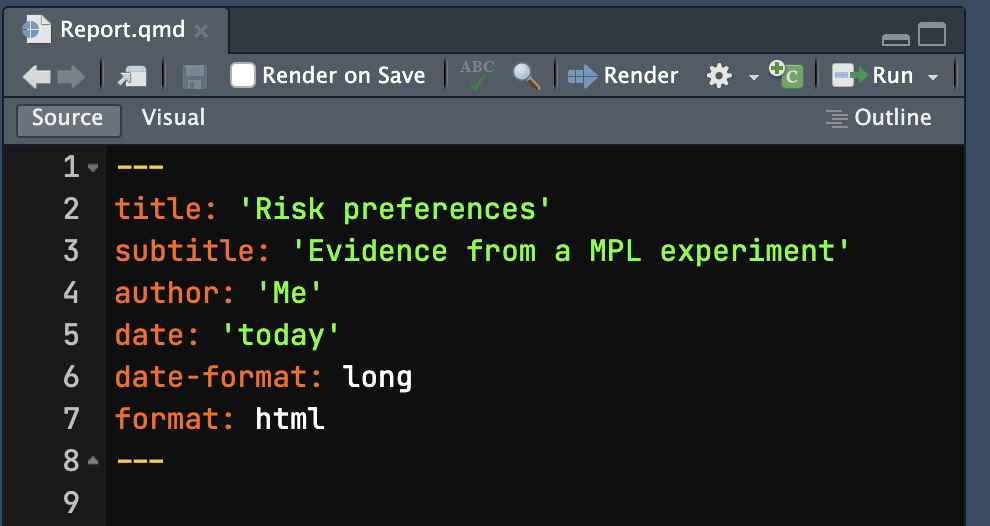

- Click on *Render*
- In Microsoft VS Code
  - Install the Quarto extension

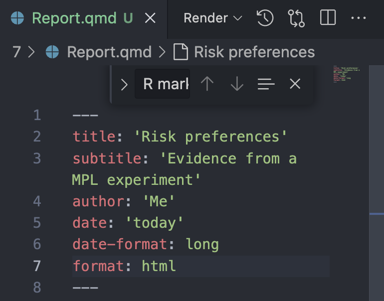

- Click on *Render*

## 3.7 An example of a R Markdown report

- See

Download Report.zip

- Source file: *Report.qmd*
- Rendered file: *Report.html*

# 4 Appendix

## 4.1 Assignemnt

- Create slides from Report.qmd
  - Hint: use the following YAML header

```
---
title: 'Risk preferences'
subtitle: 'Evidence from a MPL experiment'
author: 'Me'
date: 'today'
date-format: long
format:
    revealjs: default
---
```

## 4.2 References

## References

Wickham, Hadley. 2010. “A Layered Grammar of Graphics.” *Journal of Computational and Graphical Statistics* 19 (1): 3–28.